# Data Viz 3) Visualizing Point Patterns

## Learning Objectives

By the end of this practical lab you will be able to:

- Manipulate and re-code date and time stamps
- Create summary graphics showing the temporal attributes of point data
- Map point data using bins and density plots

## Visualizing Points

We will first read some crime data into R for the [City of Chicago, USA](https://data.cityofchicago.org/view/5cd6-ry5g). This contains those crimes which occurred during the year 2016 as of 24th December; with the attributes including the category of the crime and a variety of other information such as location and date / time. The following code imports the data, parses the date and time stamp using the base R function strptime() and also ymd_hms() from the package lubridate. We then remove unwanted columns and restrict the results to those coded as “BURGLARY”.

```r
#Load package
#install.packages("lubridate")
library(lubridate)
```

```r
# Import Crimes
crimes <- read.csv("./data/chicago_crimes_2016.csv")

#Parse date & time
crimes$New_Date <- ymd_hms((strptime(crimes$Date, "%m/%d/%Y %I:%M:%S %p",tz="UTC")))

#Subset the data to remove unwanted colums
crimes <- crimes[crimes$Primary.Type == "BURGLARY",c("ID","Latitude","Longitude","New_Date")]

# Remove crimes with no lat / lon
crimes <- crimes[!is.na(crimes$Latitude),]

#View the top of the data
head(crimes)
```

```
##           ID Latitude Longitude            New_Date
## 24  10446386 41.93145 -87.75284 2016-03-13 04:25:00
## 27  10446394 41.74114 -87.57458 2016-03-13 05:30:00
## 103 10446948 41.73346 -87.65813 2016-03-13 09:00:00
## 117 10448234 41.77770 -87.61315 2016-03-13 09:00:00
## 124 10449036 41.98388 -87.65278 2016-03-13 09:00:00
## 143 10465522 41.77596 -87.60339 2016-03-28 09:00:00
```

We can then see how the burglaries are distributed by day of the week. We use the wday() function to convert the date column into days - by adding “label = TRUE” this returns a text string relating to the day of the week (e.g. “Mon”):

```r
library(ggplot2)
```

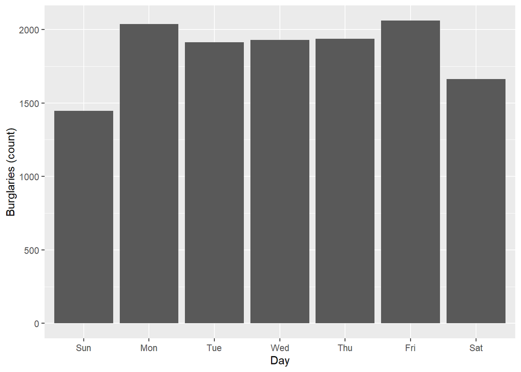

```r
ggplot(data=crimes, aes(wday(crimes$New_Date,label = TRUE))) +
    geom_bar() +
    xlab("Day") +
    ylab("Burglaries (count)")
```

We can see that in 2016 there were more recorded burglary incidences during the week. We can also look at changes month, however, this time using the month() function:

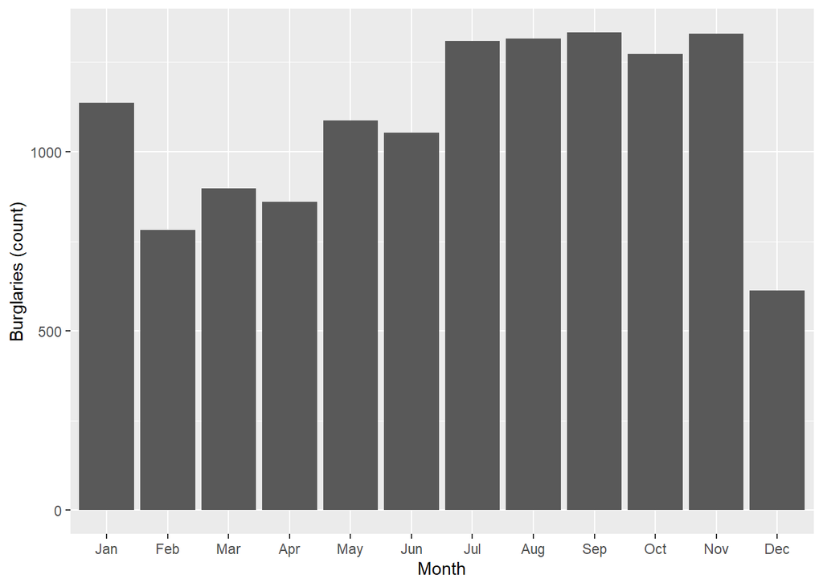

```r
ggplot(data=crimes, aes(month(crimes$New_Date,label = TRUE))) +
    geom_bar() +
    xlab("Month") +
    ylab("Burglaries (count)")
```

So far we have displayed months and days separately, however, we can also use the facet_grid option to produce separate plots for each month; and additionally add an aesthetic to the geom_bar that colors each day differently.

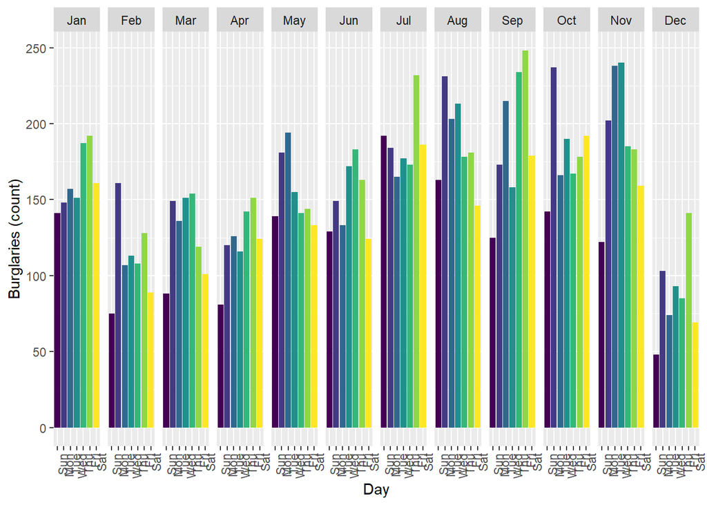

```r
ggplot(data=crimes, aes(wday(crimes$New_Date,label = TRUE))) +
    geom_bar(aes(,fill=wday(crimes$New_Date,label = TRUE))) +
    xlab("Day") +
    ylab("Burglaries (count)") +
    facet_grid(~month(crimes$New_Date,label = TRUE)) +
    theme(axis.text.x = element_text(angle = 90, hjust = 1),legend.position="none")
```

Using a similar technique we can also explore the time of the day during which burglaries have been recorded as having occurred and then view by quarter. When interpreting these data it is worth thinking about potential bias within the crime data - for example, why are so many burglaries recorded as having taken place first thing in the morning?

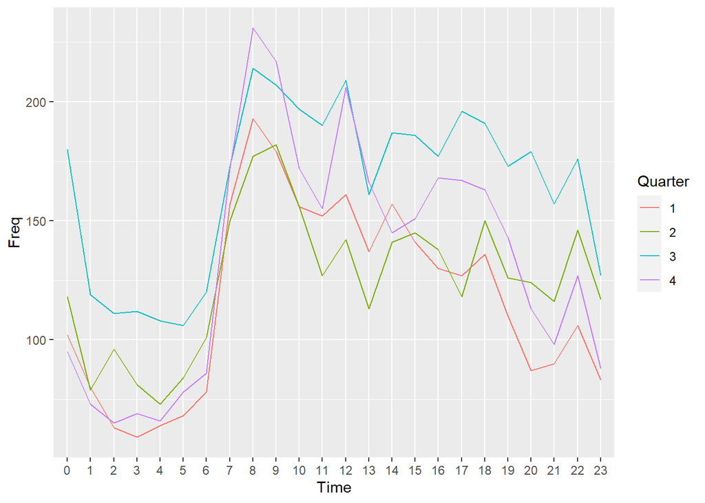

```r
#Create a summary data frame of the counts of burglaries by hour time band and quarter of the year
t <- data.frame(table(hour(crimes$New_Date),quarter(crimes$New_Date)))
colnames(t) <- c("Time","Quarter","Freq") # Name columns as something sensible
#Create plot
p <- ggplot(t, aes(x=Time, y=Freq, group=Quarter, colour = Quarter))
p + geom_line()
```

## Mapping Points

Now we are going to look at mapping some point data. Let’s plot the crimes for Chicago - the coord_map function automatically selects the appropriate projection for our map. Check that you have the R package ‘mapproj’ installed:

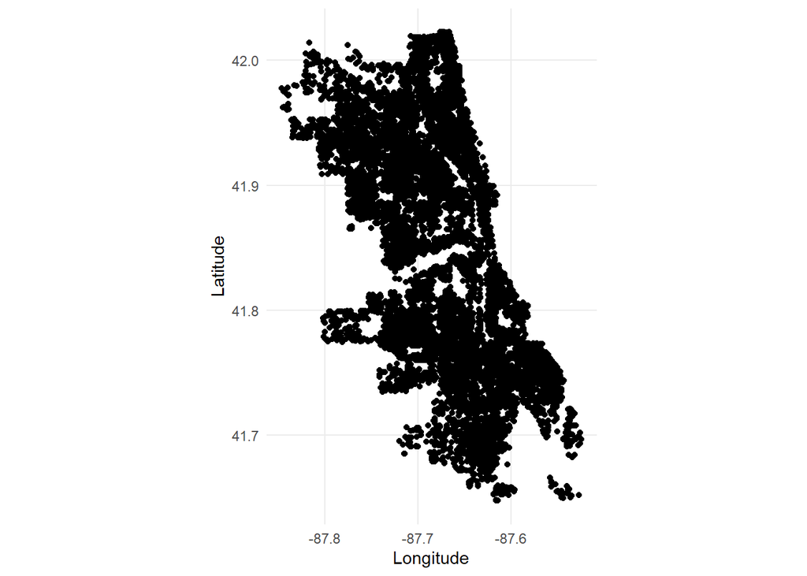

```r
#Load package
#install.packages("mapproj)
library(mapproj)
ggplot(crimes, aes(x = Longitude, y = Latitude)) +
  geom_point() +
  theme_minimal() +
  coord_map()
```

We can improve this a bit by shrinking the point size and using transparency, however, this still isn’t great as the point density is too high:

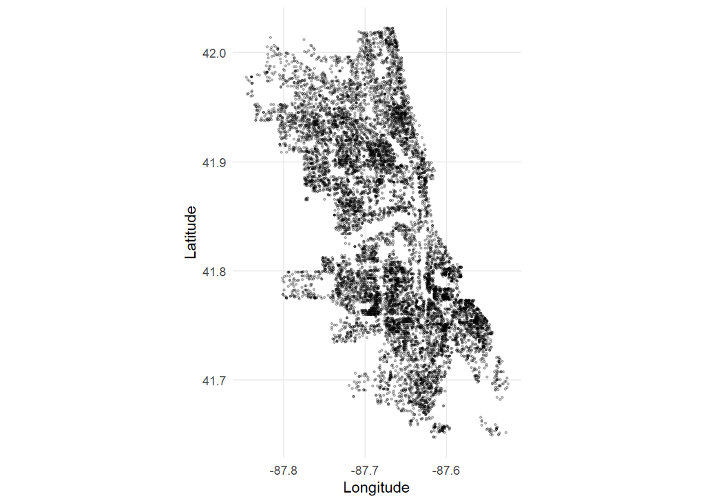

```r
ggplot(crimes, aes(x = Longitude, y = Latitude)) +
  geom_point(alpha = 0.25, size = 0.5) +
  theme_minimal() +
  coord_map()
```

One way to manage point data is to aggregate these up to a given zonal geography. However, this assumes that the data being observed have a logical bounding geography, subjecting the analyses to the Modifiable Areal Unit Problem (MAUP). When this is not the case it may be effective to spatially bin the data into a set of uniform and discrete zones. It is common for these visualizations to use either grids (squares) or hexagons; however, as with other formal zonal definitions (e.g. blocks / census tracts etc), the choice of grid or hex size may impact the patterns shown.

We can create a gridded map using the stat_bin2d function - the size of the grid is adjusted with the bins size, and creates an aggregated count within each cell:

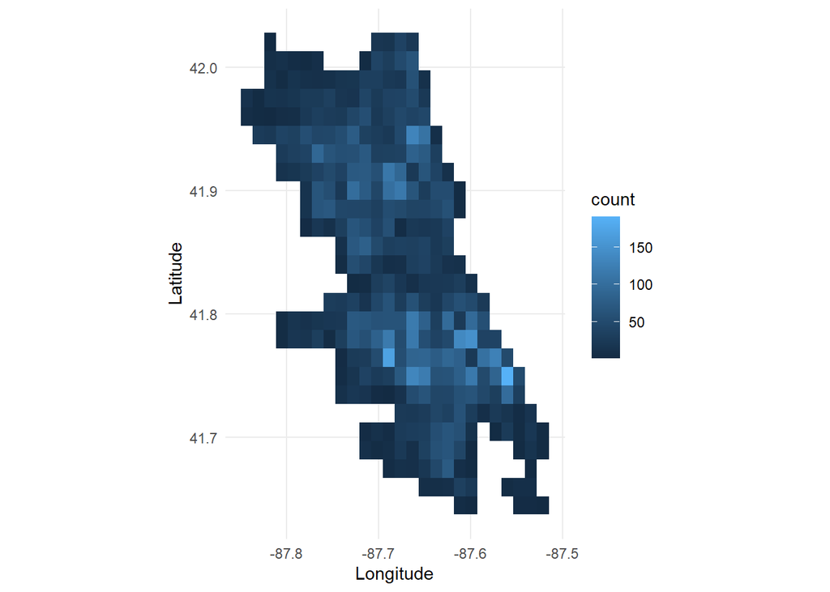

```r
ggplot(crimes, aes(x=Longitude, y=Latitude)) +
  stat_bin2d(bins = 25) +
  theme_minimal() +
  coord_map()
```

Higher numbers create a smaller grid size:

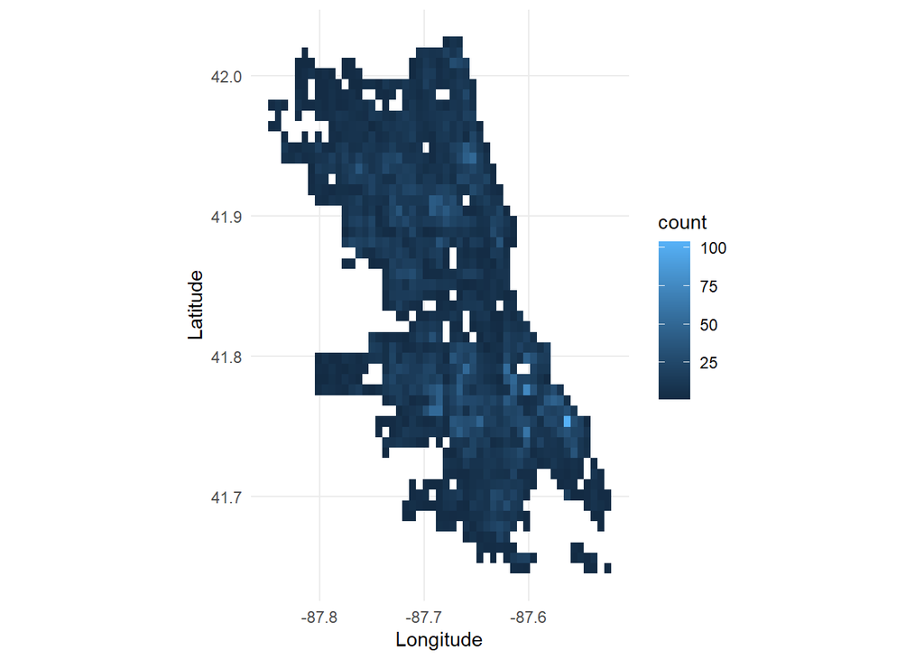

```r
ggplot(crimes, aes(x=Longitude, y=Latitude)) +
  stat_bin2d(bins = 50) +
  theme_minimal() +
  coord_map()
```

A similar representation can be produced with hexagons instead of rectangles. To aggregate to hexagons, first install the ‘hexbin’ R package:

```r
#Load package
#install.packages("hexbin")
library(hexbin)
```

Unfortunately, the geom_hex() function only works with Cartesian coordinates, so coord_map() cannot be used in this instance:

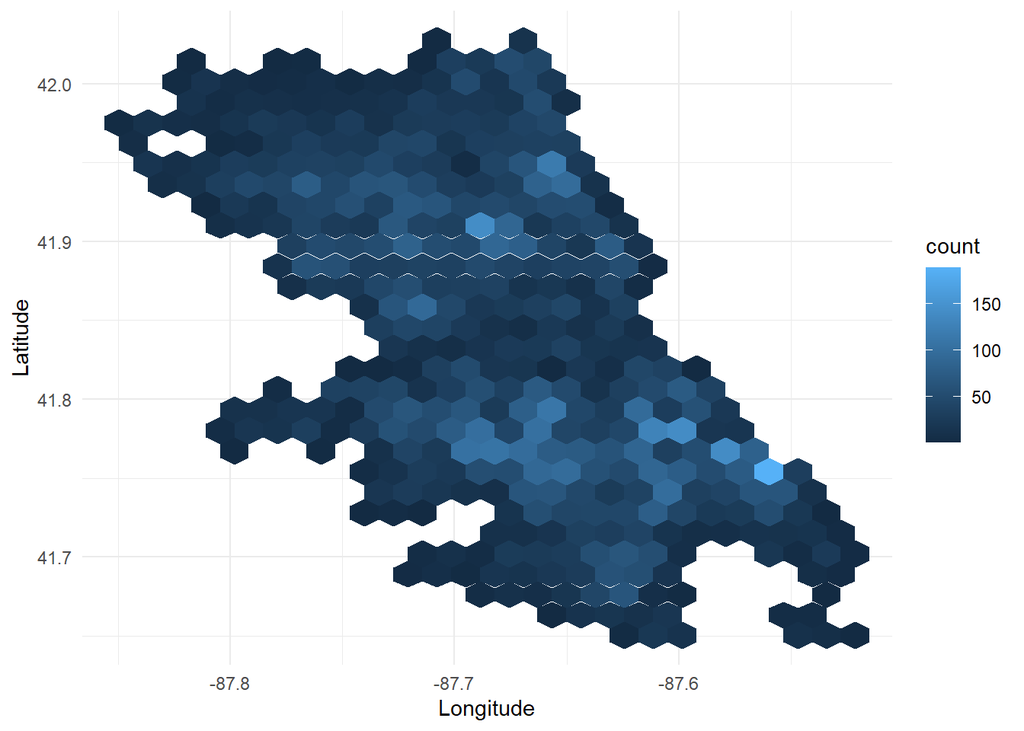

```r
ggplot(crimes, aes(x = Longitude, y = Latitude)) +
  geom_hex(bins = 25) +
  theme_minimal() +
  coord_cartesian()
```

We can then tidy the map up further, and in particular, remove the grey area and axis content from the display:

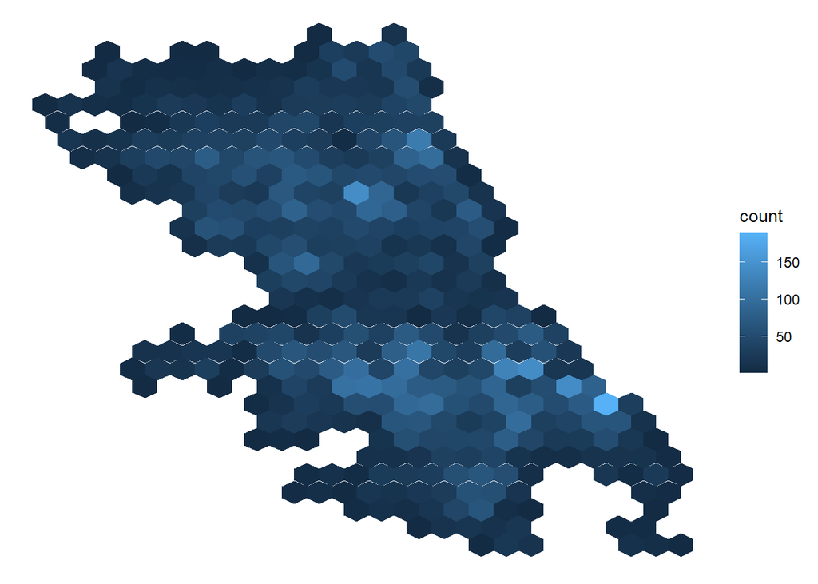

```r
ggplot(crimes, aes(x = Longitude, y = Latitude)) +
  geom_hex(bins = 25) +
  theme_bw() +
  theme(axis.line = element_blank(),
      axis.text = element_blank(),
      axis.title=element_blank(),
      axis.ticks = element_blank(),
      legend.key = element_blank(),
      panel.grid.major = element_blank(),
      panel.grid.minor = element_blank(),
      panel.border = element_blank(),
      panel.background = element_blank())
```

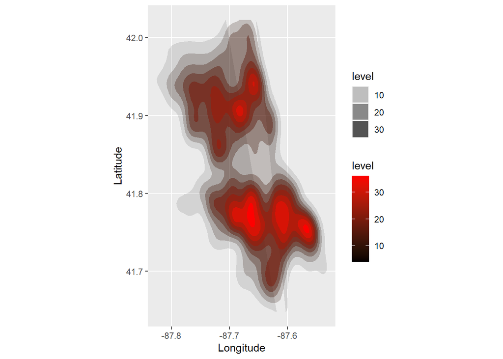

```r
ggplot(crimes) +
  stat_density2d(aes(x = Longitude, y = Latitude, fill = ..level..,alpha=..level..), bins = 10, geom = "polygon", data = crimes) +
  scale_fill_gradient(low = "black", high = "red") +
  coord_map()
```

We can extend the previous plot to add facets for two newly created variables, plus additionally remove some of the unwanted features of the previous map. First create two new columns that record the quarter and day of the week in which the burglary was recorded.

```r
#Append a quarter variable to the crimes data frame
crimes$Q <- quarter(crimes$New_Date)
#Append a day variable to the crimes data frame
crimes$D <- wday(crimes$New_Date,label = TRUE)
```

Create a plot for quarters:

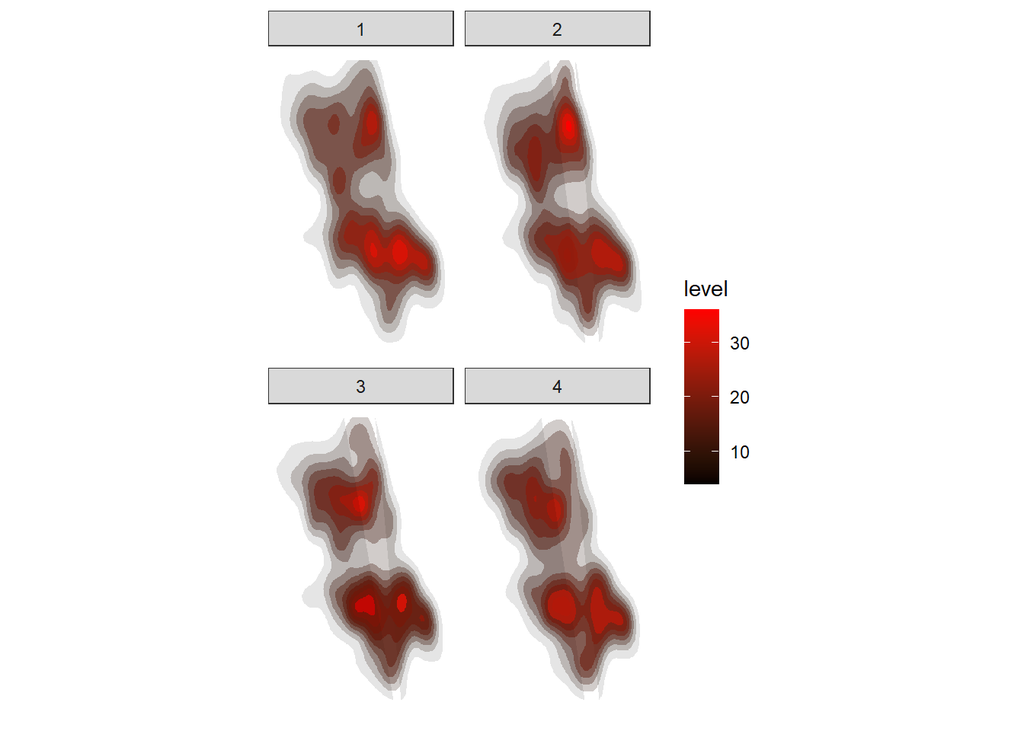

```r
# Create a plot
ggplot(crimes) +
  stat_density2d(aes(x = Longitude, y = Latitude,fill = ..level..,alpha=..level..), bins = 10, geom = "polygon", data = crimes) +
  scale_fill_gradient(low = "black", high = "red") +
  facet_wrap(~ Q) +
  guides(alpha=FALSE) +
  theme_bw() +
  theme(axis.line = element_blank(),
      axis.text = element_blank(),
      axis.title=element_blank(),
      axis.ticks = element_blank(),
      legend.key = element_blank(),
      panel.grid.major = element_blank(),
      panel.grid.minor = element_blank(),
      panel.border = element_blank(),
      panel.background = element_blank()) +
  coord_map()
```

Create a plot for days:

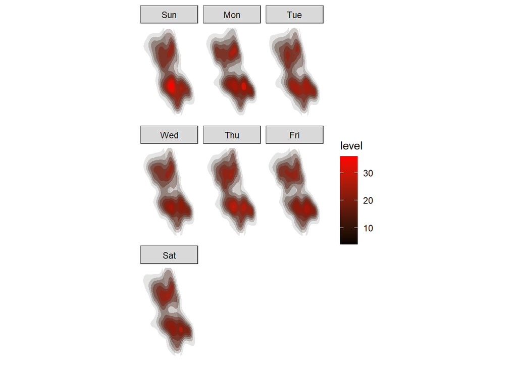

```r
# Create a plot
ggplot(crimes) +
  stat_density2d(aes(x = Longitude, y = Latitude,fill = ..level..,alpha=..level..), bins = 10, geom = "polygon", data = crimes) +
  scale_fill_gradient(low = "black", high = "red") +
  facet_wrap(~ D) +
  guides(alpha=FALSE) +
  theme_bw() +
  theme(axis.line = element_blank(),
      axis.text = element_blank(),
      axis.title=element_blank(),
      axis.ticks = element_blank(),
      legend.key = element_blank(),
      panel.grid.major = element_blank(),
      panel.grid.minor = element_blank(),
      panel.border = element_blank(),
      panel.background = element_blank()) +
  coord_map()
```

# Further resources / training

- [Statistical Analysis of Spatial and Spatio-Temporal Point Patterns](https://www.crcpress.com/Statistical-Analysis-of-Spatial-and-Spatio-Temporal-Point-Patterns-Third/Diggle/p/book/9781466560239) - models and statistical methods for analyzing spatially referenced point data